# Bayesian Linear Regression With Truncated Normal Distributions

Phil Chapman

2018-06-22

# 1 Setup

## 1.1 Load libraries

```r
library(rjags, quietly = TRUE)
library(ggplot2, quietly = TRUE)
library(dplyr, quietly = TRUE)
library(tidybayes, quietly = TRUE)
library(brms, quietly = TRUE)
library(broom, quietly = TRUE)
```

## 1.2 Simulate data

Below we simulate a dataset with two groups with a difference in mean of 50.

```r
set.seed(1238)
df <- data_frame(p1 = rbinom(1000, 1, 0.5),
              d = 50,
              data = rnorm(1000, mean = 500 + p1 * d , sd=80))
df
```

```
## # A tibble: 1,000 x 3
##       p1     d  data
##    <int> <dbl> <dbl>
##  1     1    50  512.
##  2     1    50  595.
##  3     0    50  433.
##  4     0    50  455.
##  5     0    50  518.
##  6     1    50  653.
##  7     1    50  554.
##  8     0    50  409.
##  9     0    50  545.
## 10     1    50  646.
## # ... with 990 more rows
```

Visualise this dataset:

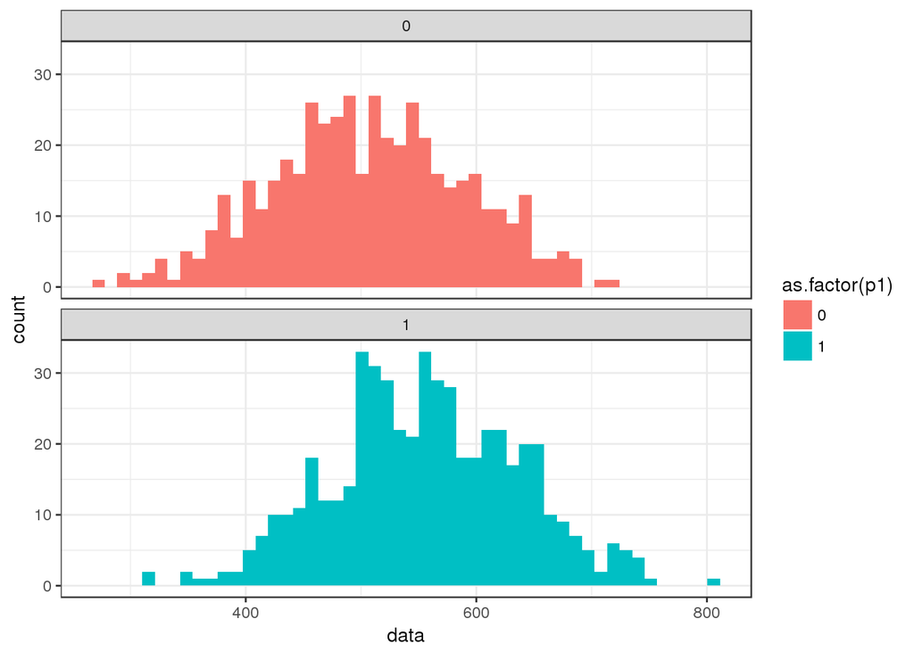

```r
ggplot(df, aes(x=data, fill=as.factor(p1))) +
  geom_histogram(bins=50) +
  facet_wrap(~as.factor(p1), ncol = 1) + theme_bw()
```

## 1.3 Truncate the data

Now truncate the data by getting rid of data above 600

```r
trunc_df <- df %>%
  filter(data < 600)
trunc_df
```

```
## # A tibble: 772 x 3
##       p1     d  data
##    <int> <dbl> <dbl>
##  1     1    50  512.
##  2     1    50  595.
##  3     0    50  433.
##  4     0    50  455.
##  5     0    50  518.
##  6     1    50  554.
##  7     0    50  409.
##  8     0    50  545.
##  9     0    50  522.
## 10     0    50  508.
## # ... with 762 more rows
```

And plot the truncated distributions:

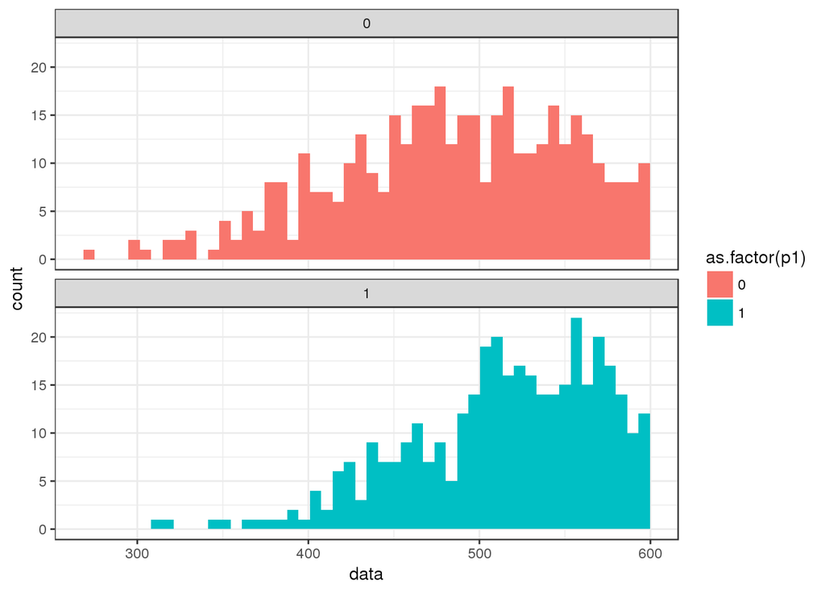

```r
ggplot(trunc_df, aes(x=data, fill=as.factor(p1))) +
  geom_histogram(bins=50) +
  facet_wrap(~as.factor(p1), ncol = 1) + theme_bw()
```

# 2 Linear Regression

Simply use linear regression to estimate the mean and difference between groups. For the non-truncated data this works as expected:

```r
m1_lm <- lm(data ~ as.factor(p1), data=df)
m1_lm
```

```
##
## Call:
## lm(formula = data ~ as.factor(p1), data = df)
##
## Coefficients:
##    (Intercept)  as.factor(p1)1
##         505.96           49.94
```

```r
tidy(m1_lm)
```

```
##             term  estimate std.error statistic     p.value
## 1    (Intercept) 505.96230  3.768664  134.2551 0.00000e+00
## 2 as.factor(p1)1  49.94332  5.216175    9.5747 7.76514e-21
```

But the estimates are way out for the truncated data.

```r
m2_lm <- lm(data ~ as.factor(p1), data=trunc_df)
m2_lm
```

```
##
## Call:
## lm(formula = data ~ as.factor(p1), data = trunc_df)
##
## Coefficients:
##    (Intercept)  as.factor(p1)1
##         483.39           31.32
```

```r
tidy(m2_lm)
```

```
##             term  estimate std.error  statistic      p.value
## 1    (Intercept) 483.39500  3.098158 156.026604 0.000000e+00
## 2 as.factor(p1)1  31.32045  4.511921   6.941712 8.233018e-12
```

# 3 Linear Regression in JAGS

## 3.1 Normal bayesian linear regression on untruncated data

### 3.1.1 Define model

The model is similar to that preivously used except that this time mu is not defined as a prior distribution, but as an equation with new parameters `a` and `b`. We then specify fairly uninformative priors for a and b.

```r
m1_jags_txt <- 'model {
for (i in 1:n) {
d[i] ~ dnorm(mu[i], tau)
mu[i] <- a + b * p1[i]
}
a ~ dunif(100,700)
b ~ dnorm(0, 0.0001)
tau <- pow(sigma, -2)
sigma ~ dunif(0, 150)
}'
```

### 3.1.2 Fit model

```r
m1_dlist <- list(d=df$data, p1=df$p1, n=nrow(df))

m1_jags <- jags.model(textConnection(m1_jags_txt),
                      data = m1_dlist,
                      n.chains = 4,
                      n.adapt = 1000)
update(m1_jags, 5000)
```

### 3.1.3 Extract samples

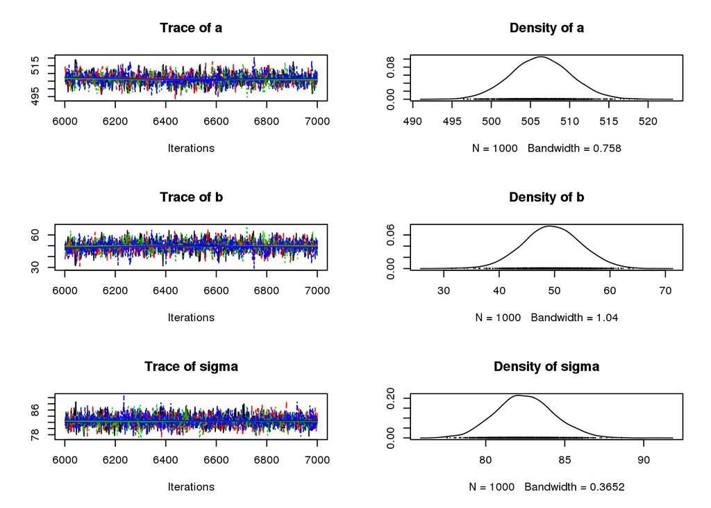

```r
samples_m1_jags <- coda.samples(m1_jags,
                           c('sigma', 'a', 'b'),
                           1000)
plot(samples_m1_jags)
```

### 3.1.4 Estimate parameters

Reminder of the true values:

```r
lm(data ~ as.factor(p1), data=df)
```

```
##
## Call:
## lm(formula = data ~ as.factor(p1), data = df)
##
## Coefficients:
##    (Intercept)  as.factor(p1)1
##         505.96           49.94
```

How did our Bayesian model do?

```r
samples_m1_jags %>%
  as.mcmc.list() %>%
  gather_samples(a,b,sigma) %>%
  tidybayes::mean_qi()
```

```
## # A tibble: 3 x 5
## # Groups:   term [3]
##   term  estimate conf.low conf.high .prob
##   <chr>    <dbl>    <dbl>     <dbl> <dbl>
## 1 a        506.     499.      514.   0.95
## 2 b         49.5     39.2      59.7  0.95
## 3 sigma     82.5     79.0      86.1  0.95
```

## 3.2 Bayesian linear regression on truncated data

### 3.2.1 Define model

The model definition is exactly the same as before except for the addition of the `T(,600)` notation to the third line:

```r
m2_jags_txt <- 'model {
for (i in 1:n) {
d[i] ~ dnorm(mu[i], tau)T(,600)
mu[i] <- a + b * p1[i]
}
a ~ dunif(100,700)
b ~ dnorm(0, 0.0001)
tau <- pow(sigma, -2)
sigma ~ dunif(0, 150)
}'
```

### 3.2.2 Fit model

```r
m2_dlist <- list(d=trunc_df$data, p1=trunc_df$p1, n=nrow(trunc_df))

m2_jags <- jags.model(textConnection(m2_jags_txt),
                      data = m2_dlist,
                      n.chains = 4,
                      n.adapt = 1000)
update(m2_jags, 5000)
```

### 3.2.3 Extract samples

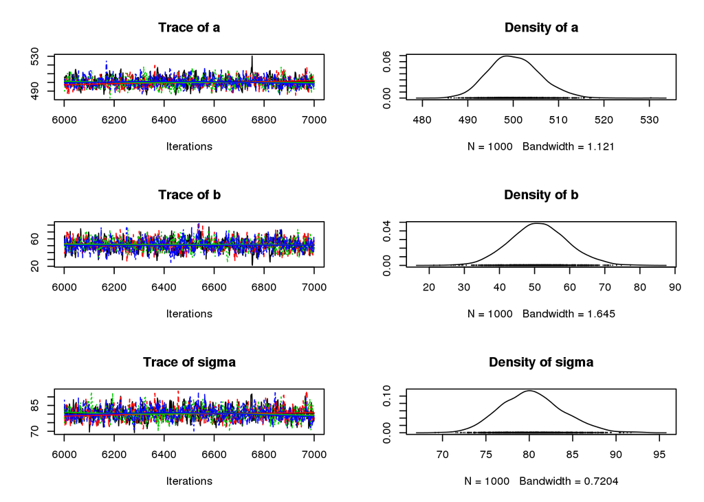

```r
samples_m2_jags <- coda.samples(m2_jags,
                           c('sigma', 'a', 'b'),
                           1000)
plot(samples_m2_jags)
```

### 3.2.4 Estimate parameters

Reminder of the true values:

```r
lm(data ~ as.factor(p1), data=df)
```

```
##
## Call:
## lm(formula = data ~ as.factor(p1), data = df)
##
## Coefficients:
##    (Intercept)  as.factor(p1)1
##         505.96           49.94
```

How did our Bayesian model from truncated data do?

```r
samples_m2_jags %>%
  as.mcmc.list() %>%
  gather_samples(a,b,sigma) %>%
  tidybayes::mean_qi()
```

```
## # A tibble: 3 x 5
## # Groups:   term [3]
##   term  estimate conf.low conf.high .prob
##   <chr>    <dbl>    <dbl>     <dbl> <dbl>
## 1 a        500.     490.      512.   0.95
## 2 b         51.3     35.7      68.2  0.95
## 3 sigma     80.3     73.8      87.9  0.95
```

## 3.3 Compare parameter estimates from truncated and full

How does the uncertainty around the estimates vary from the two models?

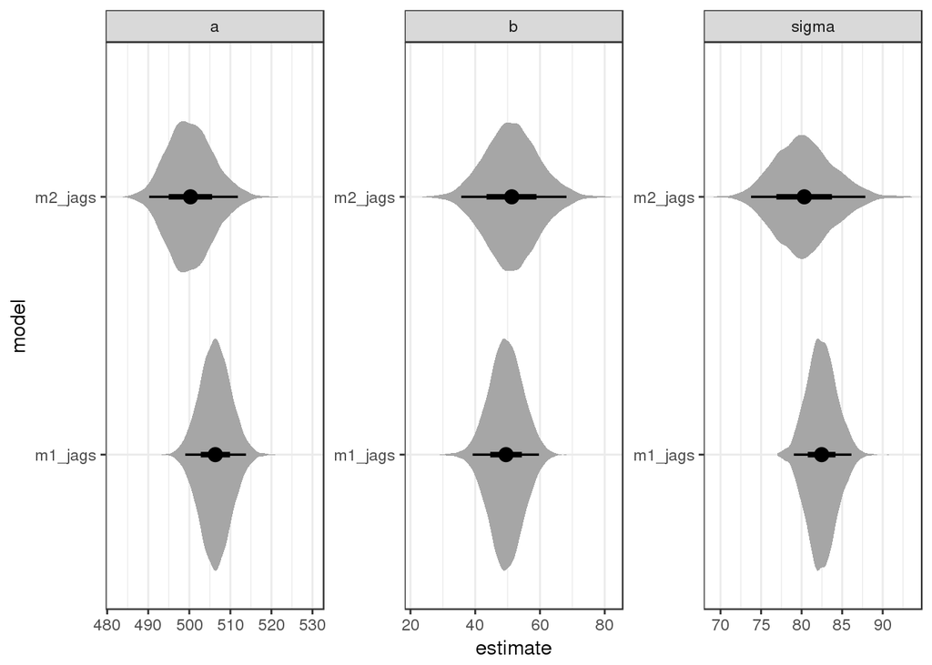

```r
plot_samples_m1_jags <- samples_m1_jags %>%
  as.mcmc.list() %>%
  gather_samples(a, b, sigma) %>%
  mutate(model='m1_jags')

plot_samples_m2_jags <- samples_m2_jags %>%
  as.mcmc.list() %>%
  gather_samples(a, b, sigma) %>%
  mutate(model='m2_jags')

bind_rows(plot_samples_m1_jags, plot_samples_m2_jags) %>%
  ggplot(aes(x=model, y=estimate)) +
  geom_eye() + coord_flip() + facet_wrap(~term, scales = 'free') + theme_bw()
```

# 4 Linear Regression in brms

The brms package is a high level interface for the Stan statistical language, which is known for using Hamiltonian MCMC which is faster and more efficient than the Gibbs sampling approach using in JAGS. This makes definition of the model much more concise.

## 4.1 Normal bayesian linear regression on untruncated data

### 4.1.1 Define model

Model definition is very similar to R’s normal linear regression modeling formula syntax. The brms package then converts this into Stan code.

```r
m1_brms_form <- brmsformula(data ~ p1)
```

### 4.1.2 Fit model

The model is fit as below. Note that the formula could be specified directly in this function call and that using multiple cores is easy.

```r
m1_brms <- brm(m1_brms_form, data=df, chains = 4, iter = 2000, cores = 4, silent = TRUE)
```

### 4.1.3 Explore model

Get a summary of the model including information on how well the model converged. Rhat of 1 and Eff.Sample close the the actual number of interations is a good thing!

```r
m1_brms
```

```
##  Family: gaussian
##   Links: mu = identity; sigma = identity
## Formula: data ~ p1
##    Data: df (Number of observations: 1000)
## Samples: 4 chains, each with iter = 2000; warmup = 1000; thin = 1;
##          total post-warmup samples = 4000
##
## Population-Level Effects:
##           Estimate Est.Error l-95% CI u-95% CI Eff.Sample Rhat
## Intercept   505.97      3.78   498.65   513.32       4000 1.00
## p1           49.94      5.21    39.98    59.97       4000 1.00
##
## Family Specific Parameters:
##       Estimate Est.Error l-95% CI u-95% CI Eff.Sample Rhat
## sigma    82.49      1.82    79.01    86.13       4000 1.00
##
## Samples were drawn using sampling(NUTS). For each parameter, Eff.Sample
## is a crude measure of effective sample size, and Rhat is the potential
## scale reduction factor on split chains (at convergence, Rhat = 1).
```

A more succinct summary is possible with `broom::tidy`

```r
lm(data ~ as.factor(p1), data=df)
```

```
##
## Call:
## lm(formula = data ~ as.factor(p1), data = df)
##
## Coefficients:
##    (Intercept)  as.factor(p1)1
##         505.96           49.94
```

```r
broom::tidy(m1_brms)
```

```
##          term    estimate std.error       lower       upper
## 1 b_Intercept   505.97471  3.782104   499.71579   512.20332
## 2        b_p1    49.93689  5.211040    41.49705    58.34782
## 3       sigma    82.48975  1.822388    79.53459    85.59013
## 4        lp__ -5837.34632  1.197701 -5839.62257 -5836.03495
```

## 4.2 Normal bayesian linear regression on truncated data

### 4.2.1 Define model

The truncated distribution notation is very simple, see `?resp_trunc` for more information:

```r
m2_brms_form <- brmsformula(data | trunc(ub=600) ~ p1)
```

### 4.2.2 Fit model

```r
m2_brms <- brm(m2_brms_form, data=trunc_df, chains = 4, iter = 2000, cores = 4, silent = TRUE)
```

### 4.2.3 Explore model

Get a summary of the model, looks like it converged OK again and although the number of effective samples is smaller, Rhat is still 1.

```r
m2_brms
```

```
##  Family: gaussian
##   Links: mu = identity; sigma = identity
## Formula: data | trunc(ub = 600) ~ p1
##    Data: trunc_df (Number of observations: 772)
## Samples: 4 chains, each with iter = 2000; warmup = 1000; thin = 1;
##          total post-warmup samples = 4000
##
## Population-Level Effects:
##           Estimate Est.Error l-95% CI u-95% CI Eff.Sample Rhat
## Intercept   499.95      5.63   489.51   511.55       2322 1.00
## p1           51.26      7.85    36.72    67.84       2094 1.00
##
## Family Specific Parameters:
##       Estimate Est.Error l-95% CI u-95% CI Eff.Sample Rhat
## sigma    80.04      3.65    73.38    87.67       1882 1.00
##
## Samples were drawn using sampling(NUTS). For each parameter, Eff.Sample
## is a crude measure of effective sample size, and Rhat is the potential
## scale reduction factor on split chains (at convergence, Rhat = 1).
```

A more succinct summary is possible with `broom::tidy` - once again we get good estimates.

```r
lm(data ~ as.factor(p1), data=df)
```

```
##
## Call:
## lm(formula = data ~ as.factor(p1), data = df)
##
## Coefficients:
##    (Intercept)  as.factor(p1)1
##         505.96           49.94
```

```r
broom::tidy(m2_brms)
```

```
##          term    estimate std.error       lower       upper
## 1 b_Intercept   499.94551  5.626682   491.09098   509.52013
## 2        b_p1    51.26106  7.849727    38.71827    64.57399
## 3       sigma    80.04176  3.649620    74.26547    86.44642
## 4        lp__ -4221.64533  1.250437 -4224.14107 -4220.29481
```

Node that we can view the Stan code that brms has produced:

```r
stancode(m1_brms)
```

```
## // generated with brms 2.3.1
## functions {
## }
## data {
##   int<lower=1> N;  // total number of observations
##   vector[N] Y;  // response variable
##   int<lower=1> K;  // number of population-level effects
##   matrix[N, K] X;  // population-level design matrix
##   int prior_only;  // should the likelihood be ignored?
## }
## transformed data {
##   int Kc = K - 1;
##   matrix[N, K - 1] Xc;  // centered version of X
##   vector[K - 1] means_X;  // column means of X before centering
##   for (i in 2:K) {
##     means_X[i - 1] = mean(X[, i]);
##     Xc[, i - 1] = X[, i] - means_X[i - 1];
##   }
## }
## parameters {
##   vector[Kc] b;  // population-level effects
##   real temp_Intercept;  // temporary intercept
##   real<lower=0> sigma;  // residual SD
## }
## transformed parameters {
## }
## model {
##   vector[N] mu = Xc * b + temp_Intercept;
##   // priors including all constants
##   target += student_t_lpdf(temp_Intercept | 3, 531, 90);
##   target += student_t_lpdf(sigma | 3, 0, 90)
##     - 1 * student_t_lccdf(0 | 3, 0, 90);
##   // likelihood including all constants
##   if (!prior_only) {
##     target += normal_lpdf(Y | mu, sigma);
##   }
## }
## generated quantities {
##   // actual population-level intercept
##   real b_Intercept = temp_Intercept - dot_product(means_X, b);
## }
```

## 4.3 Compare parameter estimates from truncated and full

How does the uncertainty around the estimates vary from the two models?

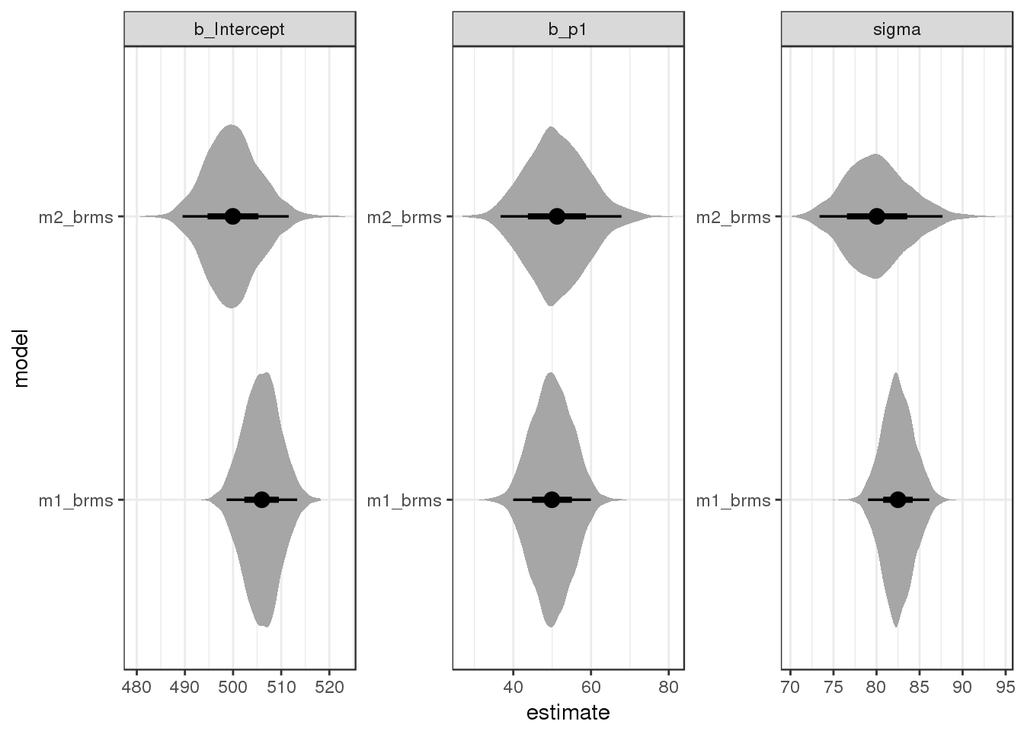

```r
plot_samples_m1_brms <- m1_brms %>%
  gather_samples(b_Intercept, b_p1, sigma) %>%
  mutate(model='m1_brms')

plot_samples_m2_brms <- m2_brms %>%
  gather_samples(b_Intercept, b_p1, sigma) %>%
  mutate(model='m2_brms')

bind_rows(plot_samples_m1_brms, plot_samples_m2_brms) %>%
  ggplot(aes(x=model, y=estimate)) +
  geom_eye() + coord_flip() + facet_wrap(~term, scales = 'free') + theme_bw()
```

Not bad but could be improved if we specified some priors rather than using default ones.

# 5 Conclusion

Following on from the previous analysis just estimating the mean of a single group, a linear regression framework can be built relatively easily. Using the `brms` package allows the model to be defined more easily, but some of the flexibility of the full language of JAGS or Stan is lost.

# 6 Session Info

```r
Sys.time()
```

```
## [1] "2018-06-22 16:37:33 UTC"
```

```r
cat(paste(readLines('/etc/docker/docker_info.txt'), '\n'))
```

```
##
##  ################################
##  # DOCKER BUILD INFORMATION
##  ################################
##
##  This is docker image: chs-stage-13-rstan:v3.1
##  Built from git commit: 0b2e558
##  See https://gitlab.dwpdata.info/pchapman/chs_docker_repo/tree/0b2e558 for Dockerfile code
##  See /etc/docker/docker_build_history.txt for provenance of this environment.
##  See /etc/docker for more information
##
##  ################################
```